# DSP anal

Skye Wills

July, 2018

### Comparable Layers

It is helpful to group horizons into similar layers for analysis. There were two general kinds of horizons sampled. The names are based on long-term soil forming factors.

*A horizons* - zones or organic matter accumulation and moderate clay depletion (for this project we include Ap horizons, which are A horizons modified substaintially by disturbance like tillage)

*Bt horizons* - zones of clay accumulation

*Lists of Horizons Used*

```
##
##      A1      A2 A2 & A3      A3     Ap1     Ap2     Bt1     Bt2     Bt3
##      10       9       1       4      42      42      12       9       1
```

```
##
##  A horizons Bt horizons    not-used
##         108          22           0
```

```
##
##                A1  A2 A2 & A3  A3 Ap1 Ap2 Bt1 Bt2 Bt3 Sum
##   A horizons   10   9       1   4  42  42   0   0   0 108
##   Bt horizons   0   0       0   0   0   0  12   9   1  22
##   not-used      0   0       0   0   0   0   0   0   0   0
##   Sum          10   9       1   4  42  42  12   9   1 130
```

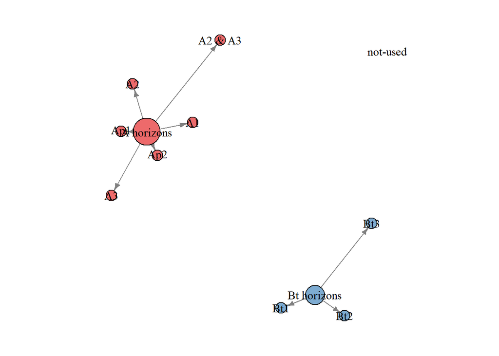

### Carbon PLOTS

Soil carbon was measured for all samples. A subset had POX-C and B-glucosidase measured. The first plots evaluate the values for each metric by depth of the sample. The second set of plots show the range of low - average - high vlaues for each general management system.

**Soil Organic Carbon** is all soil carbon in a soil sample that is not associated with minerals (like calcium carbonate or lime). It includes multiple ages and pools of organic carbon and thus it takes many years to change values due to management. Many measurements have been made for soil survey and there is lot of information about expected or typical values for any given soil.

**POX-C** is Permangante Oxidizable carbon, sometimes called ‘Active Carbon’. Thought to be related to pools of carbon that change quickly with management.

**B-glucosidase** is an extra-cellular enzyme produced by soil microbes. It is an indicator of general microbial activity. When comparing managment systems or sites on the same soil, higher levels mean higher microbial activity.

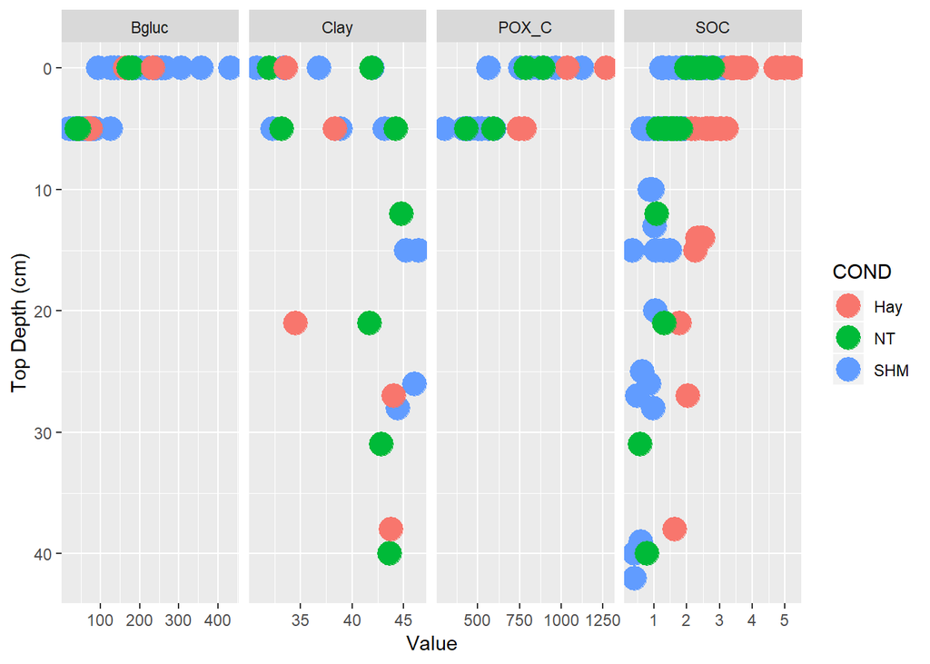

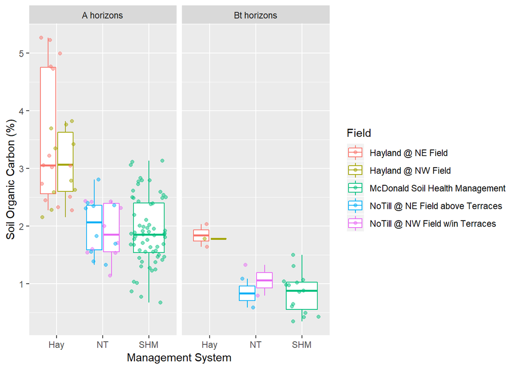

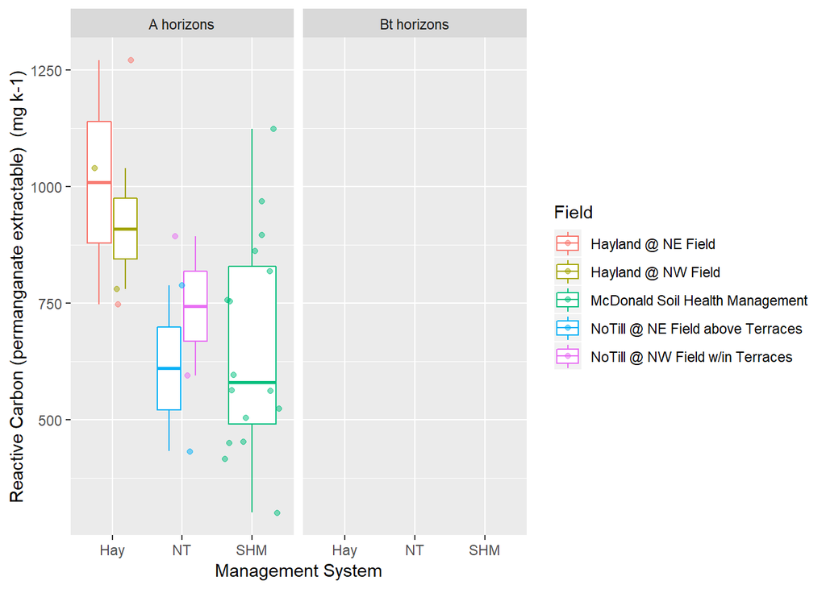

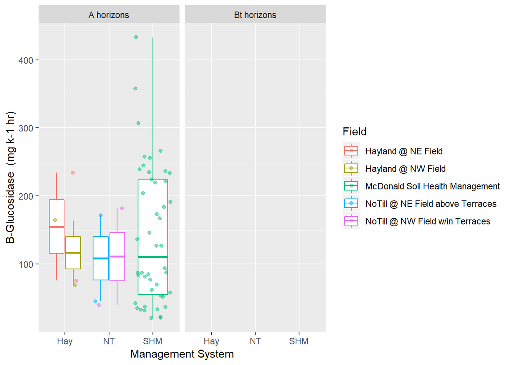

## Organic Matter

For soil survey analysis, soil carbon is measured though CO2 evolved during high temperature combustion. Then any mineral carbon is subtracted to get soil organic and converted to Organic Matter

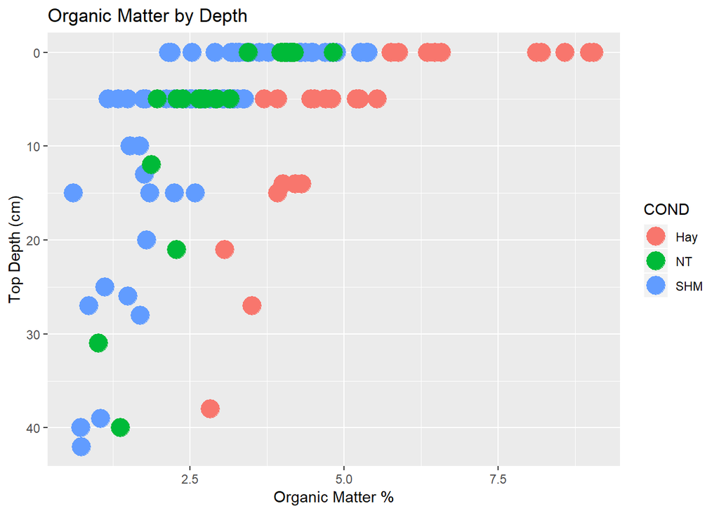

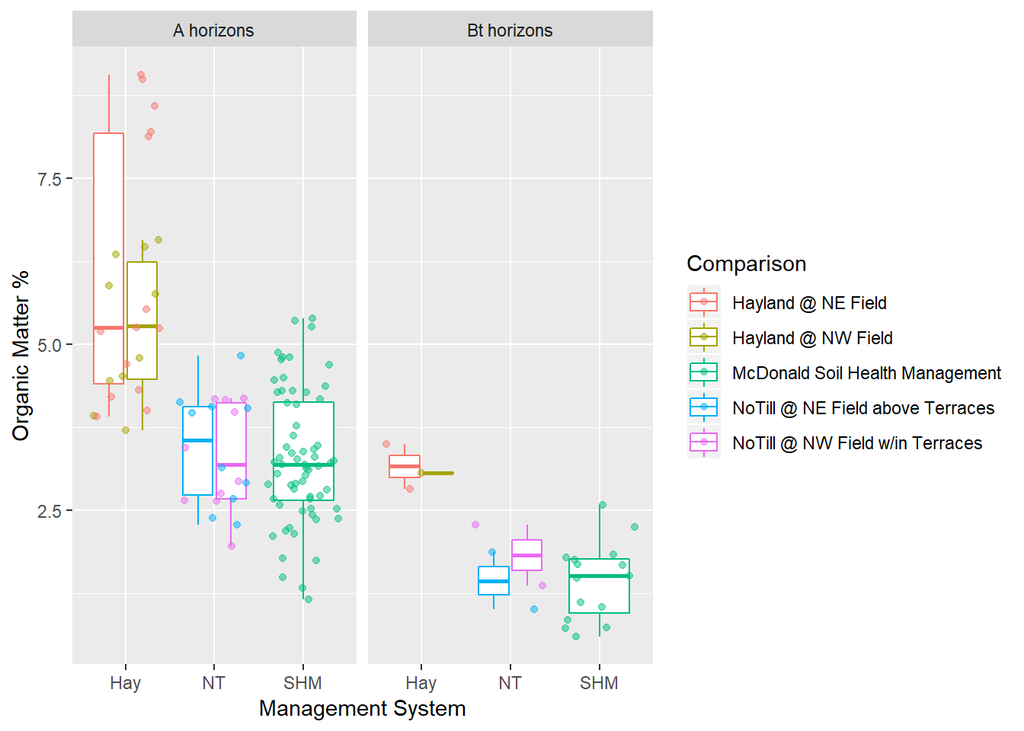

## McDonald Sites

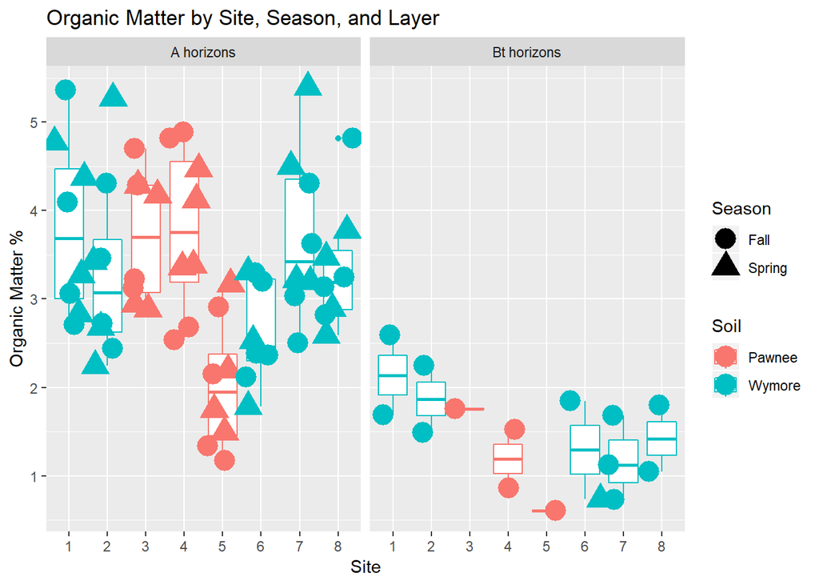

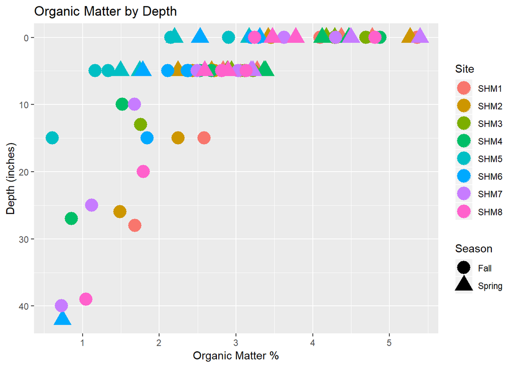

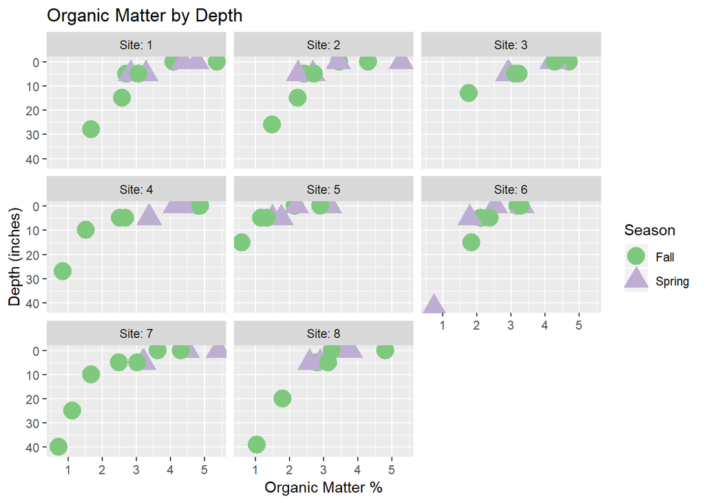

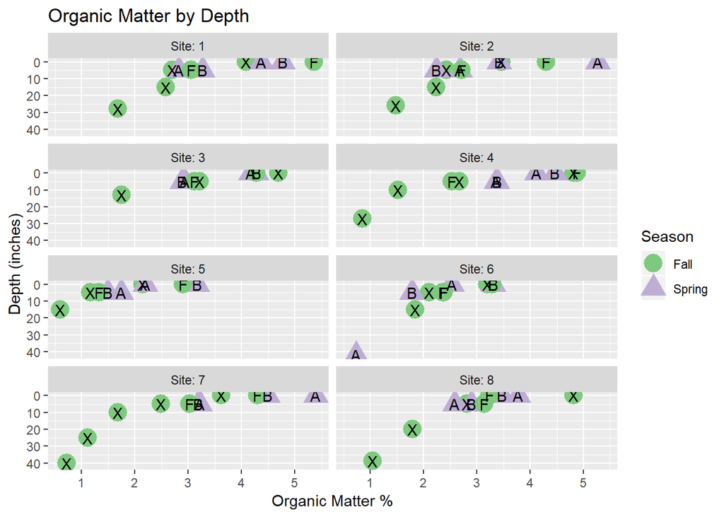

[figure not shown]

## Summary Data

Averaging sites allows us to better compare general trends and ignore within field variability.

Average Pedon Value for each Plot

| PlotID | MapUnit | Field | COND | Soil | Season | Bgluc | POX_C | SOC | OM |
| --- | --- | --- | --- | --- | --- | --- | --- | --- | --- |
| Hay12 | Wymore Silty Clay, 3 to 6 % slopes, Eroded | Hayland @ NE Field | Hay | Wymore | Fall | 105.26 | 844.72 | 3.03 | 5.22 |
| Hay9 | Shelby and Burchard clay loams, 11 to 17 % slopes | Hayland @ NW Field | Hay | Burchard | Fall | 91.62 | 841.76 | 2.58 | 4.44 |
| NT10 | Pawnee clay loam, 4 to 8 % slopes, eroded | NoTill @ NW Field w/in Terraces | NT | Pawnee | Fall | 73.81 | 665.74 | 1.64 | 2.82 |
| NT13 | Wymore Silty Clay, 3 to 6 % slopes, Eroded | NoTill @ NE Field above Terraces | NT | Wymore | Fall | 97.92 | 580.71 | 0.95 | 1.63 |
| NT13 | Wymore Silty Clay, 3 to 6 % slopes, Eroded | NoTill @ NE Field above Terraces | NT | Wymore | Spring | NaN | NaN | 1.92 | 3.29 |
| SHM1 | Wymore Silty Clay, 2 to 6 % slopes | McDonald Soil Health Management | SHM | Wymore | Fall | 84.22 | 587.62 | 1.77 | 3.05 |
| SHM1 | Wymore Silty Clay, 2 to 6 % slopes | McDonald Soil Health Management | SHM | Wymore | Spring | 121.18 | NaN | 2.01 | 3.46 |
| SHM2 | Wymore Silty Clay, 2 to 6 % slopes | McDonald Soil Health Management | SHM | Wymore | Fall | 124.53 | 553.75 | 1.50 | 2.59 |
| SHM2 | Wymore Silty Clay, 2 to 6 % slopes | McDonald Soil Health Management | SHM | Wymore | Spring | 114.14 | NaN | 1.68 | 2.89 |
| SHM3 | Pawnee clay loam, 4 to 8 % slopes, eroded | McDonald Soil Health Management | SHM | Pawnee | Fall | 137.32 | 739.63 | 1.66 | 2.85 |
| SHM3 | Pawnee clay loam, 4 to 8 % slopes, eroded | McDonald Soil Health Management | SHM | Pawnee | Spring | 86.15 | NaN | 1.91 | 3.28 |
| SHM4 | Pawnee clay loam, 4 to 8 % slopes, eroded | McDonald Soil Health Management | SHM | Pawnee | Fall | 135.25 | 710.02 | 1.40 | 2.42 |
| SHM4 | Pawnee clay loam, 4 to 8 % slopes, eroded | McDonald Soil Health Management | SHM | Pawnee | Spring | 128.50 | NaN | 2.09 | 3.60 |
| SHM5 | Pawnee clay loam, 4 to 8 % slopes, eroded | McDonald Soil Health Management | SHM | Pawnee | Fall | 56.12 | 388.45 | Inf | Inf |
| SHM5 | Pawnee clay loam, 4 to 8 % slopes, eroded | McDonald Soil Health Management | SHM | Pawnee | Spring | 83.88 | NaN | 1.10 | 1.89 |
| SHM6 | Wymore Silty Clay, 2 to 6 % slopes | McDonald Soil Health Management | SHM | Wymore | Fall | 100.67 | 529.76 | 1.35 | 2.31 |
| SHM6 | Wymore Silty Clay, 2 to 6 % slopes | McDonald Soil Health Management | SHM | Wymore | Spring | NaN | NaN | 0.94 | 1.62 |
| SHM7 | Pawnee clay loam, 4 to 8 % slopes, eroded | McDonald Soil Health Management | SHM | Wymore | Fall | 105.00 | 661.18 | 1.37 | 2.36 |
| SHM7 | Pawnee clay loam, 4 to 8 % slopes, eroded | McDonald Soil Health Management | SHM | Wymore | Spring | NaN | NaN | 2.08 | 3.57 |
| SHM8 | Wymore Silty Clay, 2 to 6 % slopes | McDonald Soil Health Management | SHM | Wymore | Fall | 128.50 | 703.85 | 1.53 | 2.62 |
| SHM8 | Wymore Silty Clay, 2 to 6 % slopes | McDonald Soil Health Management | SHM | Wymore | Spring | NaN | NaN | 1.81 | 3.11 |

Pedon Minimum Value for each Plot

| PlotID | MapUnit | Field | COND | Soil | Season | Bgluc | POX_C | SOC | OM |
| --- | --- | --- | --- | --- | --- | --- | --- | --- | --- |
| Hay12 | Wymore Silty Clay, 3 to 6 % slopes, Eroded | Hayland @ NE Field | Hay | Wymore | Fall | 105.26 | 844.72 | 2.55 | 4.39 |
| Hay9 | Shelby and Burchard clay loams, 11 to 17 % slopes | Hayland @ NW Field | Hay | Burchard | Fall | 91.62 | 841.76 | 2.27 | 3.90 |
| NT10 | Pawnee clay loam, 4 to 8 % slopes, eroded | NoTill @ NW Field w/in Terraces | NT | Pawnee | Fall | 73.81 | 665.74 | 1.33 | 2.28 |
| NT13 | Wymore Silty Clay, 3 to 6 % slopes, Eroded | NoTill @ NE Field above Terraces | NT | Wymore | Fall | 97.92 | 580.71 | 0.95 | 1.63 |
| NT13 | Wymore Silty Clay, 3 to 6 % slopes, Eroded | NoTill @ NE Field above Terraces | NT | Wymore | Spring | Inf | Inf | 1.73 | 2.97 |
| SHM1 | Wymore Silty Clay, 2 to 6 % slopes | McDonald Soil Health Management | SHM | Wymore | Fall | 69.67 | 587.62 | 1.38 | 2.37 |
| SHM1 | Wymore Silty Clay, 2 to 6 % slopes | McDonald Soil Health Management | SHM | Wymore | Spring | 96.72 | Inf | 1.89 | 3.26 |
| SHM2 | Wymore Silty Clay, 2 to 6 % slopes | McDonald Soil Health Management | SHM | Wymore | Fall | 110.00 | 553.75 | 1.14 | 1.96 |
| SHM2 | Wymore Silty Clay, 2 to 6 % slopes | McDonald Soil Health Management | SHM | Wymore | Spring | 70.75 | Inf | 1.48 | 2.54 |
| SHM3 | Pawnee clay loam, 4 to 8 % slopes, eroded | McDonald Soil Health Management | SHM | Pawnee | Fall | 129.25 | 739.63 | 1.33 | 2.29 |
| SHM3 | Pawnee clay loam, 4 to 8 % slopes, eroded | McDonald Soil Health Management | SHM | Pawnee | Spring | 75.64 | Inf | 1.86 | 3.20 |
| SHM4 | Pawnee clay loam, 4 to 8 % slopes, eroded | McDonald Soil Health Management | SHM | Pawnee | Fall | 123.00 | 710.02 | 0.88 | 1.52 |
| SHM4 | Pawnee clay loam, 4 to 8 % slopes, eroded | McDonald Soil Health Management | SHM | Pawnee | Spring | 114.00 | Inf | 2.06 | 3.55 |
| SHM5 | Pawnee clay loam, 4 to 8 % slopes, eroded | McDonald Soil Health Management | SHM | Pawnee | Fall | 52.25 | 388.45 | 1.00 | 1.73 |
| SHM5 | Pawnee clay loam, 4 to 8 % slopes, eroded | McDonald Soil Health Management | SHM | Pawnee | Spring | 81.25 | Inf | 1.08 | 1.86 |
| SHM6 | Wymore Silty Clay, 2 to 6 % slopes | McDonald Soil Health Management | SHM | Wymore | Fall | 100.67 | 529.76 | 1.20 | 2.07 |
| SHM6 | Wymore Silty Clay, 2 to 6 % slopes | McDonald Soil Health Management | SHM | Wymore | Spring | Inf | Inf | 0.62 | 1.07 |
| SHM7 | Pawnee clay loam, 4 to 8 % slopes, eroded | McDonald Soil Health Management | SHM | Wymore | Fall | 105.00 | 661.18 | 0.85 | 1.45 |
| SHM7 | Pawnee clay loam, 4 to 8 % slopes, eroded | McDonald Soil Health Management | SHM | Wymore | Spring | Inf | Inf | 2.03 | 3.49 |
| SHM8 | Wymore Silty Clay, 2 to 6 % slopes | McDonald Soil Health Management | SHM | Wymore | Fall | 128.50 | 703.85 | 1.21 | 2.07 |
| SHM8 | Wymore Silty Clay, 2 to 6 % slopes | McDonald Soil Health Management | SHM | Wymore | Spring | Inf | Inf | 1.77 | 3.04 |

Pedon Maximum Value for each Plot

| PlotID | MapUnit | Field | COND | Soil | Season | Bgluc | POX_C | SOC | OM |
| --- | --- | --- | --- | --- | --- | --- | --- | --- | --- |
| Hay12 | Wymore Silty Clay, 3 to 6 % slopes, Eroded | Hayland @ NE Field | Hay | Wymore | Fall | 105.26 | 844.72 | 3.46 | 5.96 |
| Hay9 | Shelby and Burchard clay loams, 11 to 17 % slopes | Hayland @ NW Field | Hay | Burchard | Fall | 91.62 | 841.76 | 2.99 | 5.14 |
| NT10 | Pawnee clay loam, 4 to 8 % slopes, eroded | NoTill @ NW Field w/in Terraces | NT | Pawnee | Fall | 73.81 | 665.74 | 1.83 | 3.15 |
| NT13 | Wymore Silty Clay, 3 to 6 % slopes, Eroded | NoTill @ NE Field above Terraces | NT | Wymore | Fall | 97.92 | 580.71 | 0.95 | 1.63 |
| NT13 | Wymore Silty Clay, 3 to 6 % slopes, Eroded | NoTill @ NE Field above Terraces | NT | Wymore | Spring | -Inf | -Inf | 2.21 | 3.80 |
| SHM1 | Wymore Silty Clay, 2 to 6 % slopes | McDonald Soil Health Management | SHM | Wymore | Fall | 98.76 | 587.62 | 2.17 | 3.74 |
| SHM1 | Wymore Silty Clay, 2 to 6 % slopes | McDonald Soil Health Management | SHM | Wymore | Spring | 145.63 | -Inf | 2.13 | 3.67 |
| SHM2 | Wymore Silty Clay, 2 to 6 % slopes | McDonald Soil Health Management | SHM | Wymore | Fall | 139.06 | 553.75 | 1.87 | 3.22 |
| SHM2 | Wymore Silty Clay, 2 to 6 % slopes | McDonald Soil Health Management | SHM | Wymore | Spring | 157.52 | -Inf | 1.89 | 3.24 |
| SHM3 | Pawnee clay loam, 4 to 8 % slopes, eroded | McDonald Soil Health Management | SHM | Pawnee | Fall | 145.38 | 739.63 | 1.98 | 3.41 |
| SHM3 | Pawnee clay loam, 4 to 8 % slopes, eroded | McDonald Soil Health Management | SHM | Pawnee | Spring | 96.67 | -Inf | 1.95 | 3.35 |
| SHM4 | Pawnee clay loam, 4 to 8 % slopes, eroded | McDonald Soil Health Management | SHM | Pawnee | Fall | 147.50 | 710.02 | 1.93 | 3.32 |
| SHM4 | Pawnee clay loam, 4 to 8 % slopes, eroded | McDonald Soil Health Management | SHM | Pawnee | Spring | 143.00 | -Inf | 2.12 | 3.65 |
| SHM5 | Pawnee clay loam, 4 to 8 % slopes, eroded | McDonald Soil Health Management | SHM | Pawnee | Fall | 60.00 | 388.45 | Inf | Inf |
| SHM5 | Pawnee clay loam, 4 to 8 % slopes, eroded | McDonald Soil Health Management | SHM | Pawnee | Spring | 86.50 | -Inf | 1.11 | 1.91 |
| SHM6 | Wymore Silty Clay, 2 to 6 % slopes | McDonald Soil Health Management | SHM | Wymore | Fall | 100.67 | 529.76 | 1.49 | 2.56 |
| SHM6 | Wymore Silty Clay, 2 to 6 % slopes | McDonald Soil Health Management | SHM | Wymore | Spring | -Inf | -Inf | 1.26 | 2.17 |
| SHM7 | Pawnee clay loam, 4 to 8 % slopes, eroded | McDonald Soil Health Management | SHM | Wymore | Fall | 105.00 | 661.18 | 1.90 | 3.27 |
| SHM7 | Pawnee clay loam, 4 to 8 % slopes, eroded | McDonald Soil Health Management | SHM | Wymore | Spring | -Inf | -Inf | 2.12 | 3.65 |
| SHM8 | Wymore Silty Clay, 2 to 6 % slopes | McDonald Soil Health Management | SHM | Wymore | Fall | 128.50 | 703.85 | 1.84 | 3.17 |
| SHM8 | Wymore Silty Clay, 2 to 6 % slopes | McDonald Soil Health Management | SHM | Wymore | Spring | -Inf | -Inf | 1.85 | 3.18 |

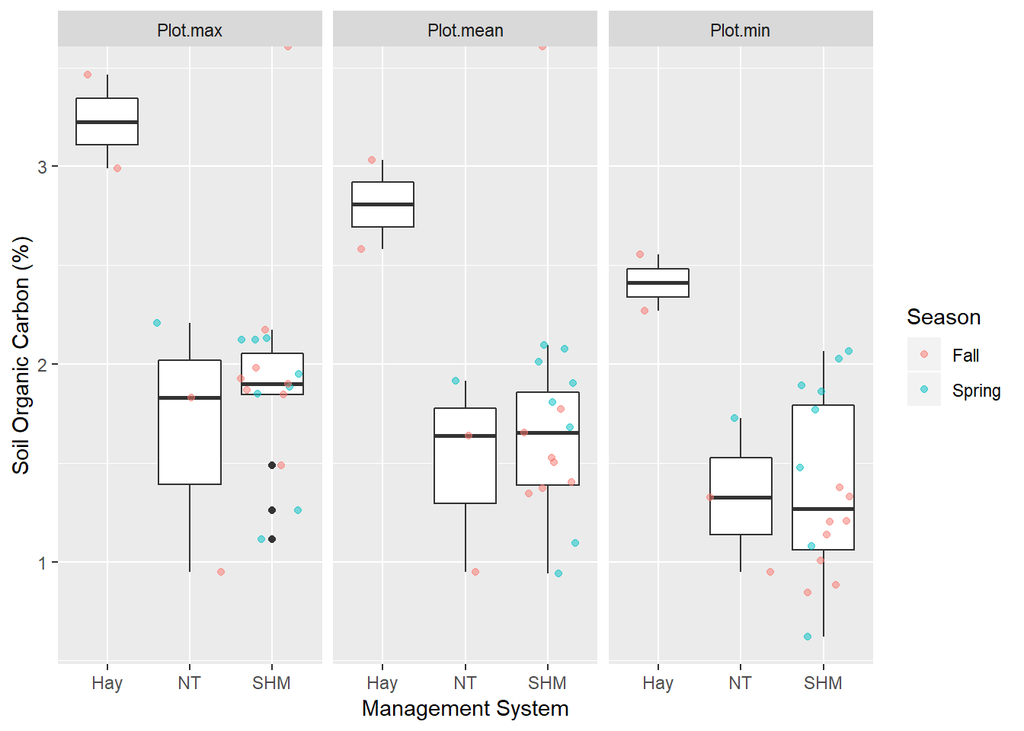

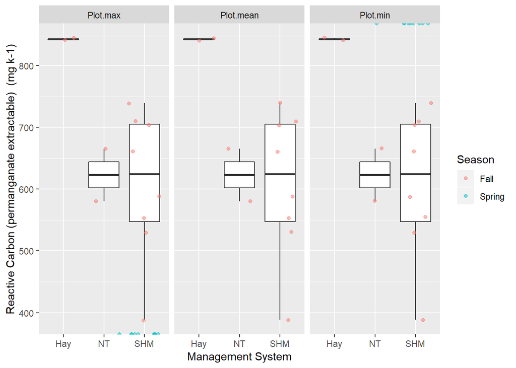

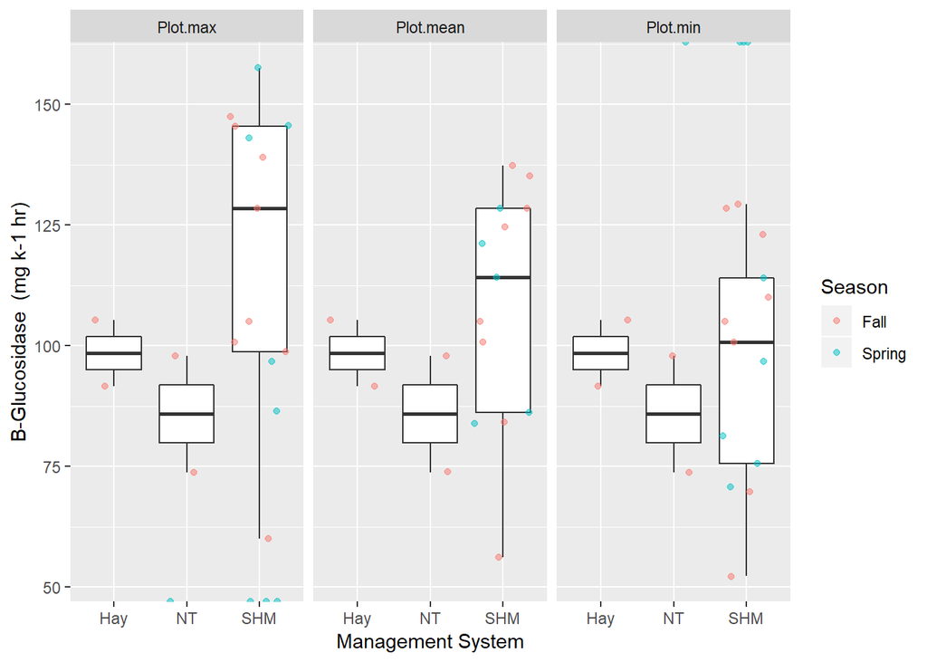